# Data Project Part 2

#### Question 7

##### 7. [4 marks] Use the data to demonstrate a statistical concept from Part I of the course. Describe the concept that you are demonstrating and interpret the findings. This should be a combination of code and written explanation.

We could use ggplot2 library to create possible histogram of count by state or by year.

Filter the data set to only show: California, our target date range, and chlamydia Create a dodged bar chart filled by gender that shows rate over year Line graph (Cases vs Year & Rate vsYear) by gender. (Makes sense? -Catalina)

#4 graphs by disease and Gender, State, Disease, Count

```r
# Package
require(gridExtra)
```

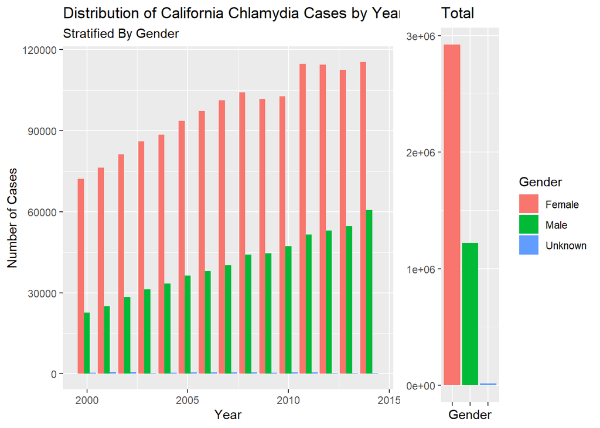

```r
# Clone CSV Table
Data  = sti_data

# Filter
Data = select (Data, State, Year, Count, Gender, Disease)

# California
Data = filter(Data, State == "California")

# Chlamydia
Data = filter(Data, Disease == "Chlamydia")

# Remove NAN
Data = na.omit(Data)

# Confirm Numeric
Data = mutate(Data, Count = as.numeric(Count))

# Distribution
P1 = ggplot(Data, aes(x = Year, y = Count, fill = Gender)) + geom_bar(stat = "identity", position = "dodge") + labs(title = "Distribution of California Chlamydia Cases by Year",subtitle = "Stratified By Gender", x = "Year", y = "Number of Cases") + theme(legend.position = "none")

# Total
Data = group_by(Data, Gender)
Data = summarize(Data, TotalCount = sum(Count))
P2 = ggplot(Data, aes(x = Gender, y = TotalCount)) + geom_bar(stat = "identity",aes(fill = Gender)) + labs(title = "Total", x = "Gender", y = "Number of Cases") + theme(axis.title.y = element_blank()) + theme(axis.text.x = element_blank())

# Arrange Into Grid
grid.arrange(P1, P2, ncol=2, nrow=1,widths = c(2,1))
```

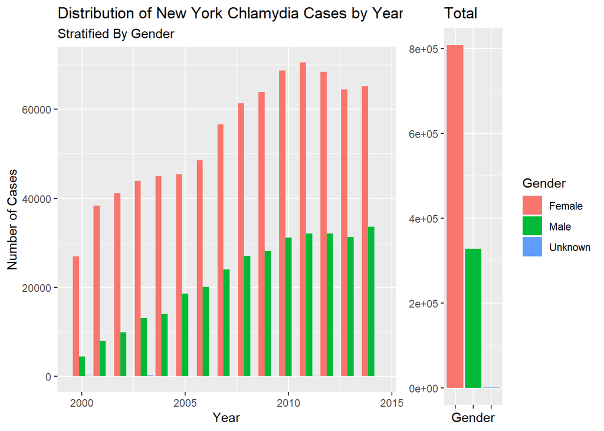

```r
Plot <- arrangeGrob(P1, P2, ncol=2, nrow=1,widths = c(2,1))

# Save
ggsave(Plot, file="California.png")
# Package
require(gridExtra)

# Clone CSV Table
Data  = sti_data

# Filter
Data = select (Data, State, Year, Count, Gender, Disease)

# California
Data = filter(Data, State == "New York")

# Chlamydia
Data = filter(Data, Disease == "Chlamydia")

# Remove NAN
Data = na.omit(Data)

# Confirm Numeric
Data = mutate(Data, Count = as.numeric(Count))

# Distribution
P1 = ggplot(Data, aes(x = Year, y = Count, fill = Gender)) + geom_bar(stat = "identity", position = "dodge") + labs(title = "Distribution of New York Chlamydia Cases by Year",subtitle = "Stratified By Gender", x = "Year", y = "Number of Cases") + theme(legend.position = "none")

# Total
Data = group_by(Data, Gender)
Data = summarize(Data, TotalCount = sum(Count))
P2 = ggplot(Data, aes(x = Gender, y = TotalCount)) + geom_bar(stat = "identity",aes(fill = Gender)) + labs(title = "Total", x = "Gender", y = "Number of Cases") + theme(axis.title.y = element_blank()) + theme(axis.text.x = element_blank())

# Arrange Into Grid
grid.arrange(P1, P2, ncol=2, nrow=1,widths = c(2,1))
```

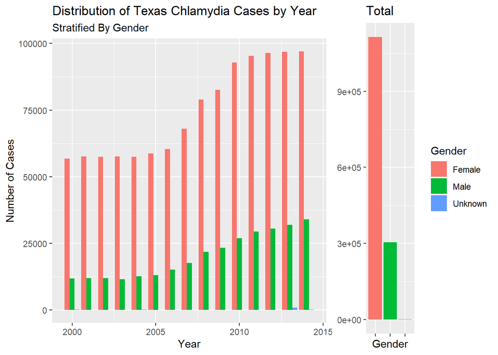

```r
Plot <- arrangeGrob(P1, P2, ncol=2, nrow=1,widths = c(2,1))

# Save
ggsave(Plot, file="NewYork.png")
# Package
require(gridExtra)

# Clone CSV Table
Data  = sti_data

# Filter
Data = select (Data, State, Year, Count, Gender, Disease)

# California
Data = filter(Data, State == "Texas")

# Chlamydia
Data = filter(Data, Disease == "Chlamydia")

# Remove NAN
Data = na.omit(Data)

# Confirm Numeric
Data = mutate(Data, Count = as.numeric(Count))

# Distribution
P1 = ggplot(Data, aes(x = Year, y = Count, fill = Gender)) + geom_bar(stat = "identity", position = "dodge") + labs(title = "Distribution of Texas Chlamydia Cases by Year",subtitle = "Stratified By Gender", x = "Year", y = "Number of Cases") + theme(legend.position = "none")

# Total
Data = group_by(Data, Gender)
Data = summarize(Data, TotalCount = sum(Count))
P2 = ggplot(Data, aes(x = Gender, y = TotalCount)) + geom_bar(stat = "identity",aes(fill = Gender)) + labs(title = "Total", x = "Gender", y = "Number of Cases") + theme(axis.title.y = element_blank()) + theme(axis.text.x = element_blank())

# Arrange Into Grid
grid.arrange(P1, P2, ncol=2, nrow=1,widths = c(2,1))
```

```r
Plot <- arrangeGrob(P1, P2, ncol=2, nrow=1,widths = c(2,1))

# Save
ggsave(Plot, file="Texas.png")
```

# Part II

In Part II of the data project, you will demonstrate a statistical concept from Part II of the course (material on midterm II, Chapters 9-12 of Baldi & Moore). You should be using the same dataset for Part II that you used in part I.

Questions: 1. [1 mark] Include your work for Part I. 2. [2 marks] Describe a quantity you will estimate as an outcome in your problem using probability notation. Are you planning to calculate marginal probabilities? Conditional probabilities? 3. [3 marks] Describe the type of theoretical distribution that is relevant for your data. i) What type of variable(s) are you investigating (continuous, categorical, ordinal, etc)? ii) What theoretical distribution that we have talked about would potentially be appropriate to use with these data (Normal, Binomial, Poisson. . . ) iii) Why is this an appropriate model for the data you are studying? 4. [4 marks] Use the data you have to demonstrate a statistical concept from Part II of the course. Describe the concept that you are demonstrating and interpret the findings. This may include code in R, a visual of some kind and text interpretation.